# R package: mvrem

Multivariate joint models with INLA — from formulae to the INLA model

Szymon M. Kiełbasa, Chiara Degan, Roula Tsonaka, Bart Mertens

Department of Biomedical Data Sciences, Section Medical Statistics, Leiden University Medical Center

# The idea

## Joint scaled models

- several **longitudinal** markers $x_1, x_2, x_3, \dots$ and one or more **outcomes** $y$, each a mixed model (own fixed and random effects)
- each outcome depends on the **current value of each marker’s linear predictor** $\eta^{(x)}$ through a coefficient $\gamma_{y,x}$
- fitted jointly with INLA, using the *copy trick*: a latent field $u$ equals $\eta^{(x)}$ (a “zero equation”) and the outcome uses $\gamma\,u$
- each equation chooses its **likelihood** (Gaussian, beta, binomial, Poisson, …) and the **prior distributions** of its hyperparameters and random effects

```
%%{init: {"themeVariables": {"fontSize": "13px"}}}%%
flowchart TB
  D1[("x1: Gaussian")] --> E1["η(x1) = β + b₀ + b₁t<br/>(correlated)"]
  D2[("x2: Poisson")] --> E2["log λ = η(x2) = β + b₀ + b₁t<br/>(uncorrelated)"]
  D3[("x3: binomial")] --> E3["logit p = η(x3) = β + b₀<br/>(intercept only)"]
  E1 -- "0 = η − u" --> U1["u(x1 → y)"]
  E2 -- "0 = η − u" --> U2["u(x2 → y)"]
  E3 -- "0 = η − u" --> U3["u(x3 → y)"]
  U1 -- "γ₁ · u" --> EY["logit μ = η(y) = β + b₀ + Σₖ γₖ uₖ"]
  U2 -- "γ₂ · u" --> EY
  U3 -- "γ₃ · u" --> EY
  EY --> Y[("y: beta")]
```

## Fitting with INLA

INLA can fit joint scaled models, but:

- is **difficult to run**: it is a separate program accessible (R interface not on CRAN)
- needs **restructured formulae**: all equations merged into one, variables renamed per equation
- needs **restructured data**: one stacked data set, response matrix
- uses **non-intuitive notation**: `f()` with `copy`, weights, `values`
- has **underdocumented specification** of likelihoods, priors, hyperparameters
- may need a **containerized environment** to be easily usable (on Macs, on shark)
- development is easier within a **devcontainer** (easy in VS Code, possible with RStudio)

Moreover, jsm:

- needs **additional equations**: one zero equation per (marker, outcome) pair
- needs **careful matching** of random-effect levels

## Can it be simplified?

The model in [jm] as INLA needs it — Gaussian, Poisson and binomial markers with correlated, uncorrelated and intercept-only random effects, a beta outcome, priors on precisions, SDs and the random-effect matrix (data not shown):

```
MX ~ -1 + y_1 + y_t +
     f(y_1_id, model = "iid", values = LEVELS$y_1_id, n = length(LEVELS$y_1_id), hyper = list(prec = list(prior = "logtnormal", param = c(0, 1)))) +
     f(y_FROM_x1_id_t, copy = "x1_TO_y_id_t", hyper = list(beta = list(fixed = FALSE, prior = "normal", param = c(0, 0.01)))) +
     f(y_FROM_x2_id_t, copy = "x2_TO_y_id_t", hyper = list(beta = list(fixed = FALSE, prior = "normal", param = c(0, 0.01)))) +
     f(y_FROM_x3_id_t, copy = "x3_TO_y_id_t", hyper = list(beta = list(fixed = FALSE, prior = "normal", param = c(0, 0.01)))) +
     x1_1 + x1_t +
     f(x1_1_id, model = "iid2d", values = LEVELS$x1_1_t_id, n = length(LEVELS$x1_1_t_id), hyper = list(theta1 = list(prior = "wishart2d", param = c(4, 1, 1, 0)))) +
     f(x1_t_id, x1_t, copy = "x1_1_id") +
     f(x1_TO_y_id_t, x1_WEIGHT, model = "iid", values = LEVELS$x1_TO_y_id_t, hyper = list(prec = list(initial = -6, fixed = TRUE))) +
     x2_1 + x2_t +
     f(x2_1_id, model = "iid", values = LEVELS$x2_1_id, n = length(LEVELS$x2_1_id), hyper = list(prec = list(prior = "pc.prec", param = c(1, 0.01)))) +
     f(x2_t_id, x2_t, model = "iid", values = LEVELS$x2_t_id, n = length(LEVELS$x2_t_id), hyper = list(prec = list(prior = "pc.prec", param = c(1, 0.01)))) +
     f(x2_TO_y_id_t, x2_WEIGHT, model = "iid", values = LEVELS$x2_TO_y_id_t, hyper = list(prec = list(initial = -6, fixed = TRUE))) +
     x3_1 + x3_t +
     f(x3_1_id, model = "iid", values = LEVELS$x3_1_id, n = length(LEVELS$x3_1_id)) +
     f(x3_TO_y_id_t, x3_WEIGHT, model = "iid", values = LEVELS$x3_TO_y_id_t, hyper = list(prec = list(initial = -6, fixed = TRUE)))
```

```
family = c("beta", "gaussian", "poisson", "binomial", "gaussian", "gaussian", "gaussian")
```

```
control.family = list(
  list(hyper = list(phi = list(prior = "loggamma", param = c(1, 0.1)))),
  list(hyper = list(prec = list(prior = "pc.prec", param = c(1, 0.01)))),
  list(),
  list(),
  list(hyper = list(prec = list(initial = 10, fixed = TRUE))),
  list(hyper = list(prec = list(initial = 10, fixed = TRUE))),
  list(hyper = list(prec = list(initial = 10, fixed = TRUE))))
```

## Our proposal: `jsm()`

The same model, written as mixed-model formulae:

```r
fit <- jsm(
  formOut  = list(y ~ t + re(1 | id, prior = halfNormalSd(1))),
  formLong = list(x1 ~ t + re(1 + t | id, prior = wishartPrec()),  # correlated
                  x2 ~ t + re(1 + t || id, prior = pcSd(1)),       # uncorrelated
                  x3 | trials(n) ~ t + (1 | id)),                  # intercept only
  familyOut  = list(y = betaFamily(phi = gammaPrec(1, 0.1))),
  familyLong = list(x1 = gaussianFamily(prec = pcSd(1)),
                    x2 = poissonFamily(), x3 = binomialFamily()),
  dataOut = d, dataLong = d
)
```

- lme4 notation, brms-style `trials()`; families and priors as functions
- every outcome is linked to every marker automatically; `scaled(x1, ...)` only for non-default settings
- INLA formula, stacked data, renaming, zero equations and level matching are generated

## `collectFormulas()`: responses and effects

| Specification | Meaning |
| --- | --- |
| `y ~ t + grp` | fixed effects (factors expand) |
| `log(y) ~ ...` | transformed response, named `y` |
| `k \| trials(n) ~ ...` | binomial: successes of `n` trials |
| `cnt \| exposure(pt) ~ ...` | counts with exposure |
| `(1 + t \| id)` | correlated intercept + slope |
| `(1 + t \|\| id)` | uncorrelated intercept, slope |
| `(1 \| id)`, `(0 + t \| id)` | intercept / slope only |
| `re(1 \| id) + re(0 + t \| id)` | two independent blocks |
| `(1 \| site:id)` | nested grouping |
| `re(1 \| id, prior = pcSd(u = 1))` | block with its prior (next slide) |
| `scaled(x1, ...)` | settings of the link to `x1` (outcomes) |

```r
p <- parseJsmFormula(
  log(x1) ~ t + grp +
    re(1 + t | id, prior = wishartPrec(df = 4)) +
    re(1 | site:id, prior = pcSd(u = 1)) +
    (0 + t || clinic),
  part = "long")
unlist(p$variables[c("response", "covariate")])
```

```
  response covariate1 covariate2
      "x1"        "t"      "grp"
```

```r
data.frame(
  term = vapply(p$re, function(b)
    deparse1(b$term), ""),
  group = vapply(p$re, `[[`, "", "group"),
  correlated = vapply(p$re, `[[`, NA,
                      "correlated"),
  prior = vapply(p$re, function(b)
    if (is.null(b$prior)) "-" else b$prior$dist, ""))
```

```
             term   group correlated   prior
1      1 + t | id      id       TRUE wishart
2     1 | site:id site:id       TRUE      pc
3 0 + t || clinic  clinic      FALSE       -
```

Checked early: one response variable per formula, no duplicates, `scaled()` only in outcomes and only for known markers, family inputs (`trials()` / `exposure()`) matching the family.

## `collectFormulas()`: priors and hyperparameters

| Constructor (defaults) | Prior on | Distribution | Parametrisation |
| --- | --- | --- | --- |
| `gammaPrec(shape = 1, rate = 5e-5)` | precision $\tau$ | [Gamma](https://en.wikipedia.org/wiki/Gamma_distribution) | shape $\alpha$, **rate** $\beta$; $E\tau = \alpha/\beta$ |
| `pcSd(u, alpha = 0.01)` | SD $\sigma$ | [Exponential](https://en.wikipedia.org/wiki/Exponential_distribution) ([PC prior](https://doi.org/10.1214/16-STS576)) | rate $\lambda = -\log(\alpha)/u$, i.e. $P(\sigma > u) = \alpha$ |
| `halfNormalSd(scale)` | SD $\sigma$ | [Half-normal](https://en.wikipedia.org/wiki/Half-normal_distribution) | Wikipedia’s $\sigma$ = `scale` (SD of the unfolded normal) |
| `halfCauchySd(scale)` | SD $\sigma$ | [Cauchy](https://en.wikipedia.org/wiki/Cauchy_distribution), folded at 0 | location 0, scale $\gamma$ = `scale` |
| `wishartPrec(df = k + 2, scale = 1)` | precision matrix $\mathbf{Q}$ | [Wishart](https://en.wikipedia.org/wiki/Wishart_distribution) | $W_k(\mathbf{V}, n)$: $n$ = `df`, $\mathbf{V}$ = `scale` ($s\,\mathbf{I}$ if scalar); $E\mathbf{Q} = n\mathbf{V}$ |

| Where | Hyperparameter arguments |
| --- | --- |
| random-effect block | `re(1 + t \| id, prior = wishartPrec(df = 4))` (`\|`, k > 1); `re(1 \| id, prior = pcSd(u = 1))` (single / `\|\|`: each effect) |
| Gaussian-type | `gaussianFamily(prec, link)`, `lognormalFamily(prec)`, `studentTFamily(prec, dof)`, `gammaFamily(prec, link)` |
| other families | `betaFamily(phi, link)`, `negBinomialFamily(size, link)`, `betaBinomialFamily(rho, link)`, `zeroInflatedPoissonFamily(type, prob)` |
| association $\gamma$ | `scaled(x1, hyper = list(beta = list(param = c(0, 1))))`: [Normal](https://en.wikipedia.org/wiki/Normal_distribution)(mean, **precision**) |

`prec` / `phi` take the four scalar priors, `size` only `gammaPrec()`; any hyperparameter also accepts a raw INLA list (`prec = list(initial = 4, fixed = TRUE)`). Priors are validated when created and translated to INLA’s `hyper` / `control.family`; no prior given → INLA default.

## The stacked data

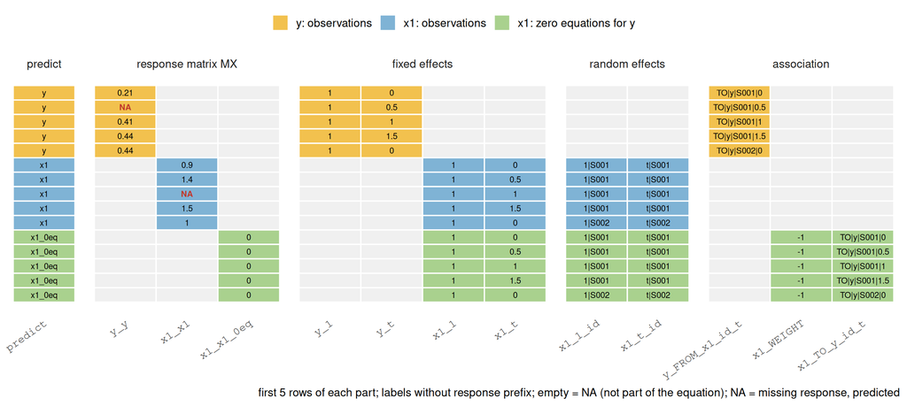

One row per observation **and** one per zero equation. Each block fills only its own response column of `MX` — that is how INLA assigns the likelihoods.

## The pipeline

| Function | Result |
| --- | --- |
| `collectFormulas()` | parsed formulae, variables, families, associations |
| `prepareData()` | one data frame per equation (rows, grouping factors, checks) |
| `buildInlaFormula()` | INLA formula, stacked data, `family`, `control.family` |
| `formatInlaFormula()` | annotated formula with its data |
| `latexEquation()` | model equations as LaTeX |
| `summarizeData()` | rows used / dropped, groups, zero equations |

Planned: a `jsm()` wrapper that runs all steps and calls INLA.

# A simple model

## Simulated data

200 subjects, 4 visits; marker `x1` with random intercept and slope, beta outcome `y` driven by the marker’s linear predictor.

```r
set.seed(1)
n <- 200
d <- data.frame(id = sprintf("S%03d", rep(seq_len(n), each = 4)),
                t  = rep(c(0, 0.5, 1, 1.5), n))
i <- as.integer(factor(d$id))
eta <- 1 + 0.5 * d$t + rnorm(n, sd = 0.5)[i] + rnorm(n, sd = 0.2)[i] * d$t
d$x1 <- eta + rnorm(nrow(d), sd = 0.2)                      # marker
mu <- plogis(-1 + 0.8 * eta)                                # gamma = 0.8
d$y <- rbeta(nrow(d), 20 * mu, 20 * (1 - mu))               # outcome, phi = 20
head(d, 4)
```

```
    id   t        x1         y
1 S001 0.0 0.9016613 0.2063624
2 S001 0.5 1.3568442 0.2130633
3 S001 1.0 1.1480540 0.4146107
4 S001 1.5 1.4814201 0.4423956
```

## Data at a glance

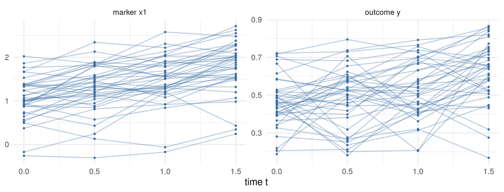

## Step 1 — the model in formulae

```r
forms <- collectFormulas(
  formOut  = list(y ~ t),                     # outcome: linked to x1 automatically
  formLong = list(x1 ~ t + (1 + t | id)),     # marker: correlated random intercept + slope
  familyOut = list(y = betaFamily())          # x1: gaussian (default)
)
forms$variables
```

```
  variable      role part formula
1        y  response  out       y
2        t covariate  out       y
3       x1  response long      x1
4        t covariate long      x1
5       id     group long      x1
```

```r
vapply(forms$out$y$scaled, `[[`, "", "target")    # associations of y
```

```
[1] "x1"
```

Every outcome is associated with every longitudinal response; `scaled(x1, ...)` in the outcome formula is only needed for non-default parameters of that link.

## Step 2 — data per equation

```r
dat <- prepareData(dataOut = d, dataLong = d, forms = forms)
head(dat$long$x1, 3)
```

```
  .key        x1   t   id
1   K1 0.9016613 0.0 S001
2   K2 1.3568442 0.5 S001
3   K3 1.1480540 1.0 S001
```

```r
head(dat$out$y, 3)
```

```
  .key         y   t   id
1   K1 0.2063624 0.0 S001
2   K2 0.2130633 0.5 S001
3   K3 0.4146107 1.0 S001
```

Variables selected, incomplete rows dropped (`na.action`), grouping factors built, row keys `.key`, responses checked against the family (beta: $0 < y < 1$).

# INLA translation

## Step 3 — the INLA formula

```r
inl <- buildInlaFormula(forms, dat)
formatInlaFormula(inl, nrows = 0)
```

```
MX ~ -1 +
   #
   # ----- y: y ~ t -----
   # family = "beta"
   #
y_1 +
y_t +
f(y_FROM_x1_id_t, copy = "x1_TO_y_id_t", hyper = list(beta = list(fixed = FALSE, prior = "normal", param = c(0, 0.01)))) +
   #
   # ----- x1: x1 ~ t + (1 + t | id) -----
   # family = "gaussian"
   # zero equations: family = "gaussian", control.family = list(hyper = list(prec = list(initial = 10, fixed = TRUE)))
   #
x1_1 +
x1_t +
f(x1_1_id, model = "iid2d", values = LEVELS$x1_1_t_id, n = length(LEVELS$x1_1_t_id)) +
f(x1_t_id, x1_t, copy = "x1_1_id") +
f(x1_TO_y_id_t, x1_WEIGHT, model = "iid", values = LEVELS$x1_TO_y_id_t, hyper = list(prec = list(initial = -6, fixed = TRUE)))
```

## What the names mean

| Term | Meaning |
| --- | --- |
| `MX` | response matrix: one column per likelihood (`y_y`, `x1_x1`, `x1_x1_0eq`) |
| `y_1`, `y_t`, `x1_1`, `x1_t` | fixed effects (covariate columns, intercept = `1`) |
| `x1_1_id` + `copy` `x1_t_id` | correlated random intercept + slope (`iid2d`), slope weighted by `x1_t` |
| `x1_TO_y_id_t` | field $u$ of the zero equation $0 = \eta^{(x_1)} - u$, one value per `(id, t)` |
| `x1_WEIGHT` | $-1$ in zero-equation rows |
| `y_FROM_x1_id_t` | scaled copy $\gamma\,u$ in the outcome |

All names come from a configurable `namingScheme()`.

```r
inl$families
```

```
       y_y      x1_x1  x1_x1_0eq
    "beta" "gaussian" "gaussian"
```

# INLA data structure

## Matching outcome and marker

```r
zr <- inl$stacks$x1$y
nrow(zr)                                       # unique (id, t) in the outcome data
```

```
[1] 800
```

```r
head(zr[c("x1_x1_0eq", "x1_1", "x1_t", "x1_1_id", "x1_t_id", "x1_WEIGHT", "x1_TO_y_id_t")], 3)
```

```
  x1_x1_0eq x1_1 x1_t   x1_1_id   x1_t_id x1_WEIGHT     x1_TO_y_id_t
1         0    1  0.0 x1|1|S001 x1|t|S001        -1   x1|TO|y|S001|0
2         0    1  0.5 x1|1|S001 x1|t|S001        -1 x1|TO|y|S001|0.5
3         0    1  1.0 x1|1|S001 x1|t|S001        -1   x1|TO|y|S001|1
```

```r
head(inl$stacks$y$main[c("y_y", "y_FROM_x1_id_t")], 3)
```

```
        y_y   y_FROM_x1_id_t
1 0.2063624   x1|TO|y|S001|0
2 0.2130633 x1|TO|y|S001|0.5
3 0.4146107   x1|TO|y|S001|1
```

Zero-equation rows evaluate $\eta^{(x_1)}$ at the **outcome’s** `(id, t)` values; the outcome row points to the same label (`x1|TO|y|S001|0`) via the copy. Rows are matched by values, not by row number — outcome visits without a marker measurement still get a zero equation.

# LaTeX formulae

## The model as equations

```r
cat(format(latexEquation(forms, dat), delim = "$$"))
```

$$\begin{aligned}
x_{1,i} &= \beta^{(x_{1})}_{0} + \beta^{(x_{1})}_{1}\, t_{i} + b^{(x_{1})}_{0,\mathrm{id}[i]} + b^{(x_{1})}_{1,\mathrm{id}[i]}\, t_{i} + \varepsilon^{(x_{1})}_{i} \\
0 &= \beta^{(x_{1})}_{0} + \beta^{(x_{1})}_{1}\, t + b^{(x_{1})}_{0,\mathrm{id}} + b^{(x_{1})}_{1,\mathrm{id}}\, t - u^{(x_{1} \to y)}_{\mathrm{id},t}, \quad \left(\mathrm{id}, t\right) \in \mathcal{D}_{y} \\
\operatorname{logit}\left(\mu^{(y)}_{i}\right) &= \beta^{(y)}_{0} + \beta^{(y)}_{1}\, t_{i} + \gamma_{y,x_{1}}\,u^{(x_{1} \to y)}_{\mathrm{id}[i],t_{i}} \\
\varepsilon^{(x_{1})}_{i} &\sim \mathcal{N}\left(0, \left(\tau^{(x_{1})}_{\varepsilon}\right)^{-1}\right) \\
\left(b^{(x_{1})}_{0,l}, b^{(x_{1})}_{1,l}\right)^\top &\sim \mathcal{N}\left(\mathbf{0}, \left(\mathbf{Q}^{(x_{1})}_{\mathrm{id}}\right)^{-1}\right), \quad l = 1, \ldots, n_{\mathrm{id}} \\
y_{i} &\sim \mathrm{Beta}\left(\mu^{(y)}_{i}\, \phi^{(y)}, \left(1 - \mu^{(y)}_{i}\right) \phi^{(y)}\right) \\
u^{(x_{1} \to y)}_{\mathrm{id},t} &\sim \mathcal{N}\left(0, \left(\tau_{x_{1} \to y}\right)^{-1}\right)
\end{aligned}$$

`latexEquation(forms, dat)` — generated from the parsed model; normals in the precision parametrisation, as in INLA.

# Beyond the simple model

## Families, inputs and priors

```r
d$n <- 10; d$k <- rbinom(nrow(d), d$n, plogis(-0.5 + 0.6 * eta))      # successes of n trials
fR <- collectFormulas(
  formOut  = list(y ~ t + scaled(x1, hyper = list(beta = list(param = c(0, 1)))),
                  k | trials(n) ~ t + re(1 | id, prior = pcSd(u = 1))),
  formLong = list(x1 ~ t + re(1 + t | id, prior = wishartPrec(df = 4, scale = diag(c(1, 0.1))))),
  familyOut  = list(y = betaFamily(phi = gammaPrec(1, 0.1)),
                    k = binomialFamily(link = "probit")),
  familyLong = list(x1 = gaussianFamily(prec = pcSd(u = 1))))
inlR <- buildInlaFormula(fR, prepareData(d, d, fR))
str(inlR$controlFamily[c("y_y", "k_k")])
```

```
List of 2
 $ y_y:List of 1
  ..$ hyper:List of 1
  .. ..$ phi:List of 2
  .. .. ..$ prior: chr "loggamma"
  .. .. ..$ param: num [1:2] 1 0.1
 $ k_k:List of 1
  ..$ control.link:List of 1
  .. ..$ model: chr "probit"
```

## … and their equations

$$\begin{aligned}
x_{1,i} &= \beta^{(x_{1})}_{0} + \beta^{(x_{1})}_{1}\, t_{i} + b^{(x_{1})}_{0,\mathrm{id}[i]} + b^{(x_{1})}_{1,\mathrm{id}[i]}\, t_{i} + \varepsilon^{(x_{1})}_{i} \\
0 &= \beta^{(x_{1})}_{0} + \beta^{(x_{1})}_{1}\, t + b^{(x_{1})}_{0,\mathrm{id}} + b^{(x_{1})}_{1,\mathrm{id}}\, t - u^{(x_{1} \to y)}_{\mathrm{id},t}, \quad \left(\mathrm{id}, t\right) \in \mathcal{D}_{y} \\
0 &= \beta^{(x_{1})}_{0} + \beta^{(x_{1})}_{1}\, t + b^{(x_{1})}_{0,\mathrm{id}} + b^{(x_{1})}_{1,\mathrm{id}}\, t - u^{(x_{1} \to k)}_{\mathrm{id},t}, \quad \left(\mathrm{id}, t\right) \in \mathcal{D}_{k} \\
\operatorname{logit}\left(\mu^{(y)}_{i}\right) &= \beta^{(y)}_{0} + \beta^{(y)}_{1}\, t_{i} + \gamma_{y,x_{1}}\,u^{(x_{1} \to y)}_{\mathrm{id}[i],t_{i}} \\
\Phi^{-1}\left(p^{(k)}_{i}\right) &= \beta^{(k)}_{0} + \beta^{(k)}_{1}\, t_{i} + b^{(k)}_{0,\mathrm{id}[i]} + \gamma_{k,x_{1}}\,u^{(x_{1} \to k)}_{\mathrm{id}[i],t_{i}} \\
\varepsilon^{(x_{1})}_{i} &\sim \mathcal{N}\left(0, \left(\tau^{(x_{1})}_{\varepsilon}\right)^{-1}\right) \\
\left(\tau^{(x_{1})}_{\varepsilon}\right)^{-1/2} &\sim \mathrm{Exp}\left(4.61\right), \quad P\left(\left(\tau^{(x_{1})}_{\varepsilon}\right)^{-1/2} > 1\right) = 0.01 \\
\left(b^{(x_{1})}_{0,l}, b^{(x_{1})}_{1,l}\right)^\top &\sim \mathcal{N}\left(\mathbf{0}, \left(\mathbf{Q}^{(x_{1})}_{\mathrm{id}}\right)^{-1}\right), \quad l = 1, \ldots, n_{\mathrm{id}} \\
\mathbf{Q}^{(x_{1})}_{\mathrm{id}} &\sim \mathcal{W}_{2}\left(4, \begin{pmatrix}1 & 0 \\ 0 & 0.1\end{pmatrix}\right) \\
y_{i} &\sim \mathrm{Beta}\left(\mu^{(y)}_{i}\, \phi^{(y)}, \left(1 - \mu^{(y)}_{i}\right) \phi^{(y)}\right) \\
\phi^{(y)} &\sim \mathrm{Gamma}\left(1, 0.1\right) \\
k_{i} &\sim \mathrm{Binomial}\left(n_{i}, p^{(k)}_{i}\right) \\
b^{(k)}_{0,l} &\sim \mathcal{N}\left(0, \left(\tau^{(k)}_{0,\mathrm{id}}\right)^{-1}\right), \quad l = 1, \ldots, n_{\mathrm{id}} \\
\left(\tau^{(k)}_{0,\mathrm{id}}\right)^{-1/2} &\sim \mathrm{Exp}\left(4.61\right), \quad P\left(\left(\tau^{(k)}_{0,\mathrm{id}}\right)^{-1/2} > 1\right) = 0.01 \\
u^{(x_{1} \to y)}_{\mathrm{id},t} &\sim \mathcal{N}\left(0, \left(\tau_{x_{1} \to y}\right)^{-1}\right) \\
u^{(x_{1} \to k)}_{\mathrm{id},t} &\sim \mathcal{N}\left(0, \left(\tau_{x_{1} \to k}\right)^{-1}\right)
\end{aligned}$$

## Supported families

| Constructor | INLA | Hyperparameters | LHS input |
| --- | --- | --- | --- |
| `gaussianFamily()`, `studentTFamily()`, `lognormalFamily()` | `gaussian`, `t`, `lognormal` | `prec` (`dof`) |  |
| `gammaFamily()`, `betaFamily()` | `gamma`, `beta` | `prec`, `phi` |  |
| `poissonFamily()`, `negBinomialFamily()` | `poisson`, `nbinomial` | (`size`) | `exposure()` |
| `binomialFamily()`, `betaBinomialFamily()` | `binomial`, `betabinomial` | (`rho`) | `trials()` |
| `zeroInflatedPoissonFamily()`, `zeroInflatedNegBinomialFamily()` | `zeroinflated…0/1` | `prob` (`size`) | `exposure()` |
| `inlaFamily()` | any non-survival | any | both |

Priors: `gammaPrec()`, `pcSd()`, `halfNormalSd()`, `halfCauchySd()`, `wishartPrec()` — or raw INLA `hyper` entries.

# Fitting (preview)

## Hand-assembled INLA call

|  | true | mean | sd |
| --- | --- | --- | --- |
| y: intercept | -1.0 | -0.99 | 0.05 |
| y: t | 0.0 | 0.01 | 0.04 |
| x1: intercept | 1.0 | 1.01 | 0.04 |
| x1: t | 0.5 | 0.51 | 0.02 |
| x1: residual precision | 25.0 | 21.68 | 1.45 |
| y: beta precision phi | 20.0 | 18.20 | 0.93 |
| gamma (x1 -> y) | 0.8 | 0.79 | 0.04 |

`inla(inl$formula, family = inl$families, control.family = inl$controlFamily, data = <stacked data>)` recovers the simulated values (200 subjects). The `jsm()` wrapper will do this assembly.

# Status

## Where we are

- **done**: formula parsing, data preparation, INLA formula and stacked data, families with `control.family`, `trials()` / `exposure()`, priors for random effects and family hyperparameters, LaTeX, data summary
- **next**: `jsm()` wrapper and fitting, priors in `scaled()`, survival outcomes (`inla.surv`)
- **placeholders** (to be decided): default prior of the scaling coefficient, fixed precisions of the zero equations

# Extras

## Development container

`.devcontainer/` — a ready-to-use environment, no local INLA installation:

- image based on `rocker/geospatial` (R 4.5) with **INLA**, `lme4`, `devtools`, Quarto
- VS Code: *Dev Containers: Reopen in Container*; the repository is mounted at `/home/rstudio/project`
- VS Code extensions: R, Quarto, Live Server, Claude Code
- **RStudio Server** on port 8787

```bash
git clone -b devel-ai \
  https://github.com/LUMC/mvrem.git
code mvrem   # -> Reopen in Container
```

```r
devtools::load_all()
devtools::test()
```

## Non-AI vs AI development

- 1st implementation (human-written, GitHub Copilot):
  - INLA formula and data were generated
  - no lme4 input (lack of proper specification)
- 2nd implementation (human-written, GitHub Copilot):
  - working, limited support for complex model specifications and priors
- 3rd implementation (Claude Code written):
  - **no single line of R code** written manually
  - problem approached in small steps with prior (?deep?) understanding
  - auto-generated code, documentation, **tests**
  - iterative refinement based on **auto-testing** and human feedback
  - no hallucinations observed (all code and documentation are grounded in the task)
  - broader support for complex model specifications, priors, latex
  - some deeper coding mistakes (which I made in the 2nd implementation and I did not properly describe), were also made by Claude Code

## More material

- `README.md` — installation and an end-to-end example
- `CODE_EXAMPLES.Rmd` / `.html` — all functions with their output, including validation errors
- `summarizeData()` — rows used per equation, missing values, zero equations
- `namingScheme()` — rename every column / field of the INLA model
- `presentation/mvrem-demo.qmd` — this presentation (`quarto render presentation/mvrem-demo.qmd`)